# Spark: RDDs and Pair RDDs

Georgios Gousios and Burcu Kulahcioglu Ozkan

10 October 2025

# Processing Data with Spark

# The World Before Spark

## Parallelism

Parallelism is about speeding up computations by using multiple processors.

- **Task parallelism**: Different computations performed on the same data
- **Data parallelism**: Apply the same computation on dataset partitions

When processing big data, *data parallelism* is used to move computations close to the data, instead of moving data in the network.

## Issues with data parallelism

- Latency: Operations are 1.000x (disk) or 1.000.000x (network) slower than accessing data in memory
- (Partial) failures: Computations on 100s of machines may fail at any time

This means that our programming model and execution should hide (but not forget!) those.

## Map/Reduce

Map/Reduce is a general computation framework, loosely based on functional programming[1]. It assumes that data exists in a K/V store

The `map` and `reduce` functions supplied by the user have associated types:

- `map(K1, V1) -> List[(K2, V2)]`
- `reduce((K2, List[V2])) -> List[(K3, V3)]`

Map/Reduce as a system was proposed by Dean & Ghemawat [2], along with the GFS.

## Examples for MapReduce Use Cases:

- Number of occurrences of each word in a large set of documents to compute `(word, N)`
- Count of URL Access Frequency to compute `(targetURL, N)`
- Reverse Web-Link Graph to compute `(targetURL, List<sourceURLS>)`
- Filtering records
- Top `k` records

## Map/Reduce execution overview

- DFS chunks are assigned to Map tasks processing each chunk into a sequence of KV pairs.
- Periodically, the buffered pairs are written to local disk.
- The keys are divided among all Reduce tasks.
- Reduce tasks work on each key separately and combine all the values associated with a specific key.

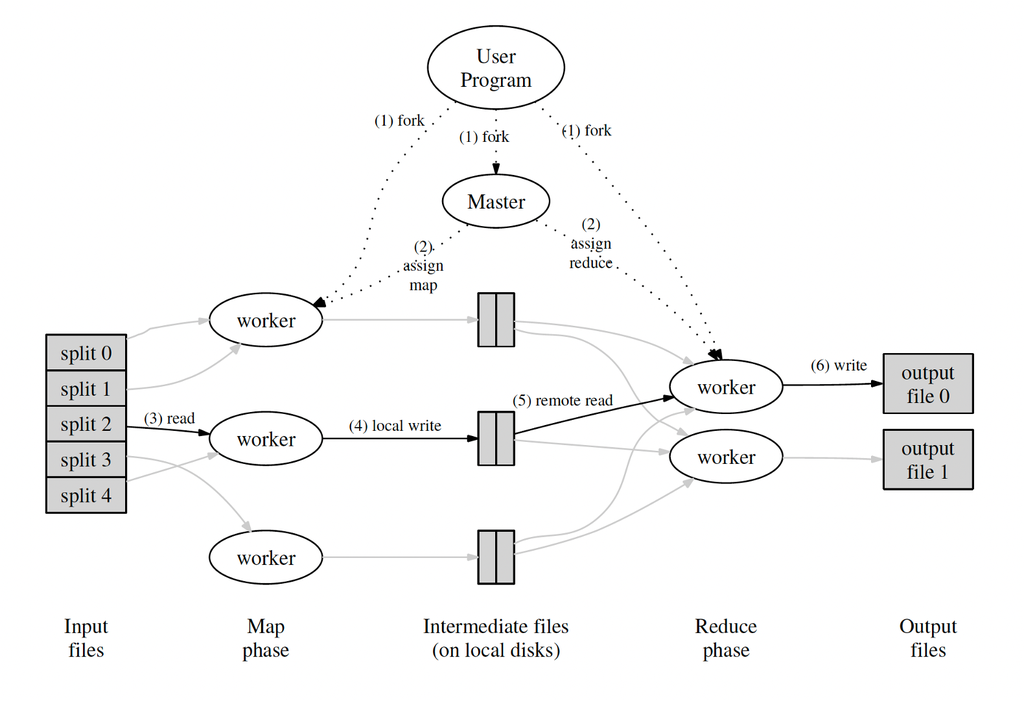

## Hadoop: OSS Map/Reduce

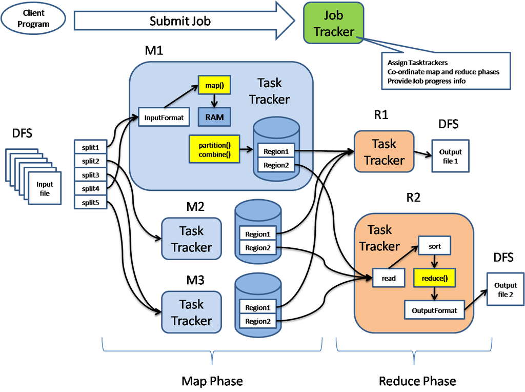

Hadoop cluster

## Hadoop: Pros and Cons

What is good about Hadoop: *Fault tolerance*

Hadoop was the first framework to enable computations to run on 1000s of commodity computers.

What is wrong: *Performance*

- Before each Map or Reduce step, Hadoop writes to HDFS
- Hard to express iterative problems in M/R
  - All machine learning problems are iterative

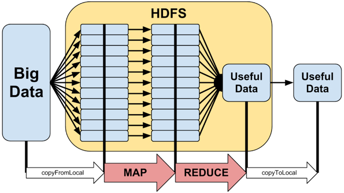

The Hadoop Workflow

## DryadLINQ

**Optional reading (not part of the exam material)**

Microsoft’s DryadLINQ combined the Dryad distributed execution engine with the LINQ language for defining queries.

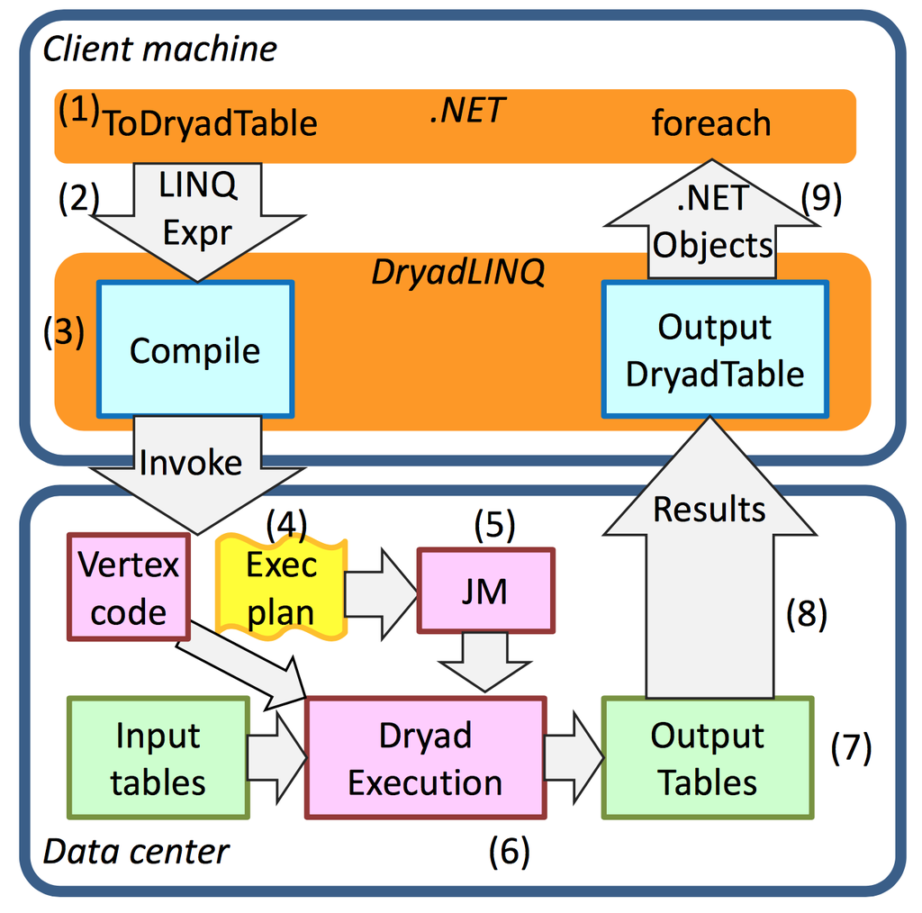

DryadLINQ architecture

## FlumeJava

**Optional reading (not part of the exam material)**

Google’s FlumeJava attempted to provide a few simple abstractions for programming data-parallel computations. These abstractions are higher-level than those provided by MapReduce, and provide better support for pipelines.

```java
PTable<String,Integer> wordsWithOnes =
  words.parallelDo( new DoFn<String, Pair<String,Integer>>() {
    void process(String word,
                 EmitFn<Pair<String,Integer>> emitFn) {
      emitFn.emit(Pair.of(word, 1));
    }
  }, tableOf(strings(), ints()));

PTable<String,Collection<Integer>>
  groupedWordsWithOnes = wordsWithOnes.groupByKey();

PTable<String,Integer> wordCounts =
  groupedWordsWithOnes.combineValues(SUM_INTS);
```

# Spark and RDDs

## What is Spark?

Spark is on open source cluster computing framework.

- automates distribution of data and computations on a cluster of computers
- provides a fault-tolerant abstraction to distributed datasets
- is based on functional programming primitives
- provides two abstractions to data, list-like (RDDs) and table-like (Datasets)

## Resilient Distributed Datasets (RDDs)

RDDs are the core abstraction that Spark uses.

RDDs make datasets distributed over a cluster of machines look like a Scala collection. RDDs:

- are immutable
- reside (mostly) in memory
- are transparently distributed
- feature all FP programming primitives
  - in addition, more to minimize shuffling

In practice, `RDD[A]` works like Scala’s `List[A]`

## Counting words with Spark

```scala
// http://classics.mit.edu/Homer/odyssey.mb.txt
val rdd = sc.textFile("./datasets/odyssey.mb.txt")
rdd
  .flatMap(l => l.split(" "))          // Split file in words
  .map(x => (x, 1))                    // Create key,1 pairs
  .reduceByKey((acc, x) => acc + x)    // Count occurrences of same pairs
  .sortBy(x => x._2, false)            // Sort by number of occurrences
  .take(50)                            // Take the first 50 results
  .foreach(println)
```

## How to create an RDD?

RDDs can only be created in the following 3 ways

1. Reading data from external sources

```scala
val rdd1 = sc.textFile("hdfs://...")
val rdd2 = sc.textFile("file://odyssey.txt")
val rdd3 = sc.textFile("s3://...")
```

. . .

2. Convert a local memory dataset to a distributed one

```scala
val xs: Range = Range(1, 10000)
val rdd: RDD[Int] = sc.parallelize(xs)
```

. . .

3. Transform an existing RDD

```scala
rdd.map(x => x.toString) //returns an RDD[String]
```

## RDDs are lazy!

There are two types of operations we can do on an RDD:

- **Transformation:** Applying a function that returns a new RDD. They are *lazy*.
- **Action:** Request the computation of a result. They are *eager*.

```scala
// This just sets up the pipeline
val result = rdd
  .flatMap(l => l.split(" "))
  .map(x => (x, 1))

// Side-effect, triggers computation
result.foreach(println)
```

## Common transformations on RDDs

**`map`: Apply $f$ on all items in the RDD and return an RDD of the result.**

$RDD[A].map(f: A \rightarrow B) : RDD[B]$

. . .

**`flatMap`: Apply $f$ on all RDD contents, return an RDD with the contents of all intermediate iterators.**

$RDD[A].flatMap(f: A \rightarrow Iterable[B]): RDD[B]$

. . .

**`filter`: Apply predicate $p$, return items that satisfy it.**

$RDD[A].filter(p: A \rightarrow Boolean): RDD[A]$

## Examples of RDD transformations

All uses of articles in the Odyssey

```scala
val odyssey = sc.textFile("datasets/odyssey.mb.txt")
                 .flatMap(_.split(" "))

odyssey.map(_.toLowerCase)
        .filter(Seq("a", "the").contains(_))
```

**Q:** How can we find uses of all regular verbs in past tense?

. . .

```scala
odyssey.filter(x => x.endsWith("ed"))
```

**Q:** How can we remove all punctuation marks?

. . .

```scala
odyssey.map(x => x.replaceAll("\\p{Punct}", ""))
```

## More examples of RDD transformations

**Q:** How can we find uses of distinct regular verbs in past tense?

```scala
odyssey.filter(x => x.endsWith("ed")).distinct
```

. . .

**Q:** How can we sort the RDD?

```scala
odyssey.sortBy(x => x)
```

. . .

**Q:** How can we sample data from the RDD?

```scala
val trainAndTestData = odyssey.randomSplit(Array(0.8, 0.2))
```

## Common actions on RDDs

**`collect`: Return all elements of an RDD**

$RDD[A].collect() : Array[A]$

. . .

**`take`: Return the first *n* elements of the RDD**

$RDD[A].take(n): Array[A]$

. . .

**`reduce`, `fold`: Combine all elements to a single result of the same type.**

$RDD[A].reduce(f: (A, A) \rightarrow A): A$

. . .

**`aggregate`: Aggregate the elements of each partition, and then the results for all the partitions**

$RDD[A].aggr(init: B)(seqOp: (B, A) \rightarrow B, combOp: (B, B) \rightarrow B): B$

## Examples of RDD actions

How many words are there (using `reduce`)?

```scala
val odyssey = sc.textFile("datasets/odyssey.mb.txt").flatMap(_.split(" "))

odyssey.map(x => 1).reduce((a,b) => a + b)
```

How many words are there (using `aggregate`)?

```scala
odyssey.map(x => 1).aggregate(0)(_ + _, _ + _)
```

How to calculate average of a collection of integers (using `aggregate`)?

```scala
val inputRdd = sc.parallelize(List(1, 2, 3, 4, 5))
val forAvg = inputRdd.aggregate((0 ,0))((acc, value) => (acc._1 + value, acc._2 + 1),
  (acc1, acc2) => (acc1._1 + acc2._1, (acc1._2 + acc2._2)))
val avg = forAvg._1.toDouble / forAvg._2.toDouble
```

## Pair RDDs

RDDs can represent any complex data type, if it can be iterated. Spark treats RDDs of the type `RDD[(K,V)]` as special, named PairRDDs, as they can be both iterated and indexed.

Operations such as `join` are only defined on Pair RDDs, meaning that we can only combine RDDs if their contents can be indexed.

We can create Pair RDDs by applying an indexing function, using `keyBy` function, or by grouping records:

```scala
val rdd = sc.parallelize(List("foo", "bar", "baz")) // RDD[String]

val pairRDD = rdd.map(x => (x.charAt(0), x))  // RDD[(Char, String)]
pairRDD.collect // Array((f,foo), (b,bar), (b,baz))

val pairRDD2 = rdd.keyBy(x => x.toLowerCase.head) // RDD[(Char, String)]
pairRDD2.collect // Array((f,foo), (b,bar), (b,baz))

val pairRDD3 = rdd.groupBy(x => x.charAt(0))  // RDD[(Char, Iterable(String))]
pairRDD3.collect // Array((b,CompactBuffer(bar, baz)), (f,CompactBuffer(foo)))
```

## Transformations on Pair RDDs

The following functions are only available on `RDD[(K,V)]`

**`reduceByKey`: Merge the values for each key using an associative and commutative reduce function**

$reduceByKey(f: (V, V) \rightarrow V): RDD[(K, V)]$

. . .

**`aggregateByKey`: Aggregate the values of each key, using given combine functions and a neutral “zero value”**

$aggrByKey(zero: U)(f: (U, V) \rightarrow U, g: (U, U) \rightarrow U): RDD[(K, U)]$

. . .

**`join`: Return an RDD containing all pairs of elements with matching keys**

$join(b: RDD[(K, W)]): RDD[(K, (V, W))]$

## Pair RDD examples: `groupByKey` and `reduceByKey`

```scala
val odyssey = sc.textFile("sample.txt").flatMap(_.split(" "))
val words = odyssey.map(c => (c, 1))
```

Word count using `groupByKey`:

```scala
val counts = words.groupByKey() // RDD[(String, Iterable[Int])]
  .map(row => (row._1, row._2.sum)) // RDD[(String, Int)]
  .collect() // Array[(String, Int)]
```

Word count using `reduceByKey`:

```scala
val counts2 = words.reduceByKey(_ + _) // RDD[(String, Int)]
  .collect()  // Array[(String, Int)]
```

**Q:** It’s more efficient to use `reduceByKey` over `groupByKey`. Why?

## Pair RDD example: `aggregateByKey`

Word count using `aggregateByKey`:

```scala
  val counts3 = words.aggregateByKey(0)(_ + _, _ + _) // RDD[(String, Int)]
```

How can we count the number of occurrences of part of speech elements?

```scala
object PartOfSpeech {
  sealed trait Word
  case object Verb extends Word
  case object Noun extends Word
  case object Article extends Word
  case object Other extends Word
}

def partOfSpeech(w: String): Word = ???

odyssey.groupBy(partOfSpeech)
      .aggregateByKey(0)((acc, x) => acc + x.size,
                          (x, y) => x + y)
```

## Pair RDD example: `join`

```scala
case class Person(id: Int, name: String)
case class Addr(id: Int, person_id: Int,
                address: String, number: Int)

val pers = sc.textFile("pers.csv") // id, name
val addr = sc.textFile("addr.csv") // id, person_id, street, num

val ps = pers.map(_.split(",")).map(x => Person(x(0).toInt, x(1)))
val as = addr.map(_.split(",")).map(x => Addr(x(0).toInt, x(1).toInt,
                                             x(2), x(3).toInt))
```

**Q:** What are the types of `ps` and `as`? How can we join them?

. . .

```scala
val pairPs = ps.keyBy(_.id) // RDD[(Int, Person)]
val pairAs = as.keyBy(_.person_id) // RDD[(Int, Addr)]

val addrForPers = pairAs.join(pairPs) // RDD[(Int, (Addr, Person))]
```

## Join types

Given a “left” `RDD[(K,A)]` and a “right” `RDD[(K,B)]`

- Inner Join (`join`): The result contains only records that have the keys in both RDDs.
- Outer joins (`left/rightOuterJoin`): The result contains records that have keys in either the “left” or the “right” RDD in addition to the inner join results.

$left.loj(right) : RDD[(K,(A, Option[B]))]$ $left.roj(right) : RDD[(K,(Option[A], B))]$

- Full outer join: The result contains records that have keys in any of the “left” or the “right” RDD in addition to the inner join results.

$left.foj(right) : RDD[(K,(Option[A], Option[B]))]$

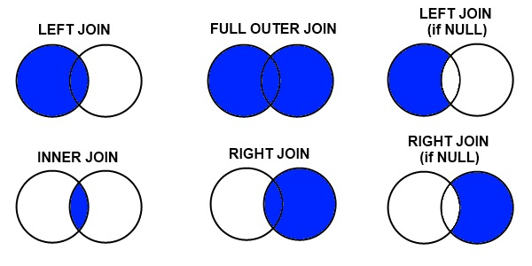

Types of joins

# RDDs under the hood

[figure not shown]

## Internals

From the [RDD.scala](https://github.com/apache/spark/blob/v2.2.0/core/src/main/scala/org/apache/spark/rdd/RDD.scala#L61), line 61.

Internally, each RDD is characterized by five main properties:

- A list of partitions
- A function for computing each split
- A list of dependencies on other RDDs
- Optionally, a Partitioner for key-value RDDs
- Optionally, a list of preferred locations to compute each split on

**D:** Why does an RDD need are all those?

## Partitions

Even though RDDs might give the impression of continuous memory blocks spread across a cluster, data in RDDs is split into *partitions*.

Partitions define a unit of computation and persistence: any Spark computation transforms a partition to a new partition.

If during computation a machine fails, Spark will redistribute its partitions to other machines and restart the computation *one those partitions only*.

The partitioning scheme of an application is configurable; better configurations lead to better performance.

## How does partitioning work?

Spark supports 3 types of partitioning schemes:

- **Default partitioning:** Splits in equally sized partitions, without knowing the underlying data properties.

Extended partitioning is only configurable on Pair RDDs.

- **Range partitioning:** Takes into account the natural order of keys to split the dataset in the required number of partitions. Requires keys to be naturally ordered and keys to be equally distributed across the value range.
- **Hash partitioning:** Calculates a hash over each item *key* and then produces the modulo of this hash to determine the new partition. This is equivalent to:

```scala
key.hashCode() % numPartitions
```

## Partition dependencies

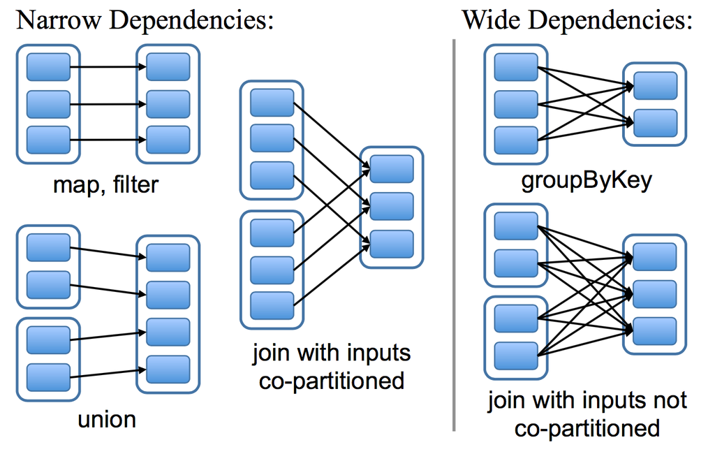

Partition Dependencies

**Narrow dependencies:** Each partition of the source RDD is used by at most one partition of the target RDD

**Wide dependencies:** Multiple partitions in the target RDD depend on a single partition in the source RDD.

## Shuffling

When operations need to calculate results using a common characteristic (e.g. a common key), this data needs to reside on the same physical node. This is the case with all “wide dependency” operations. The process of re-arranging data so that similar records end up in the same partitions is called *shuffling*.

Shuffling is very expensive as it involves moving data across the network and possibly spilling them to disk (e.g. if too much data is computed to be hosted on a single node). Avoid it at all costs!

*See [this link](https://0x0fff.com/spark-architecture-shuffle/) for a great write up on Spark shuffling*

### Shuffling example

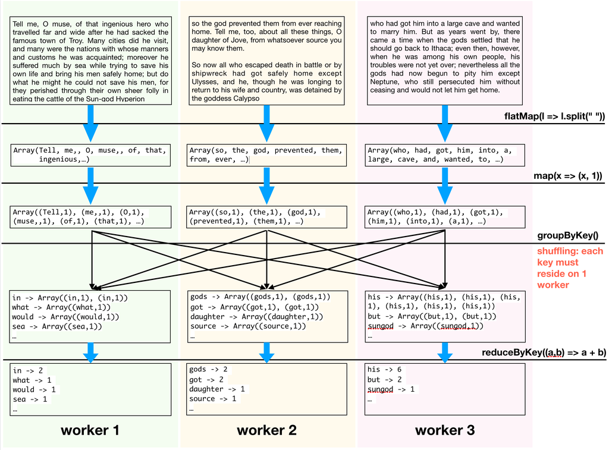

Shuffling explained

### Choose transformations to minimize shuffles:

Recall `groupByKey` and `reduceByKey`:

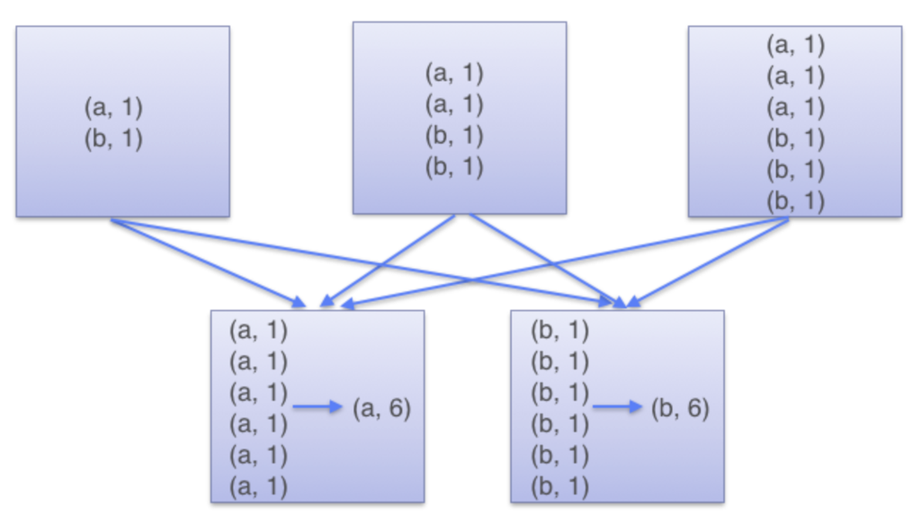

```scala
val counts1 = rdd.groupByKey()
  .map(row => (row._1, row._2.sum))
  .collect()
```

```scala
val counts2 = rdd.reduceByKey(_ + _)
  .collect()
```

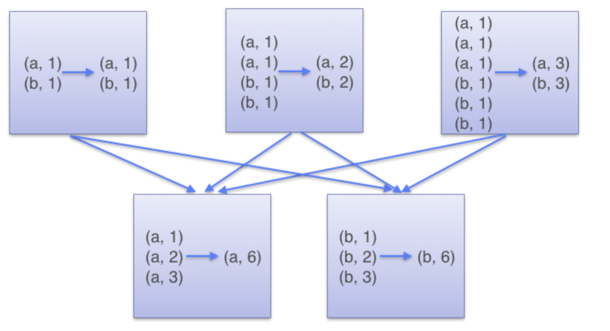

## RDD lineage

RDDs contain information on how to compute themselves, including dependencies to other RDDs. Effectively, RDDs create a directed acyclic graph of computations.

Lineage information allow an RDD to be traced to its ancestors.

To demonstrate this, consider the following example:

```scala
val rdd1 = sc.parallelize(0 to 10)
val rdd2 = sc.parallelize(10 to 100)
val rdd3 = rdd1.cartesian(rdd2)
val rdd4 = rdd3.map(x => (x._1 + 1, x._2 + 1))
```

**Q**: What are the computation dependencies here?

. . .

```
scala> rdd4.toDebugString
res3: String =
(16) MapPartitionsRDD[3] at map at <console>:30 []
 |   CartesianRDD[2] at cartesian at <console>:28 []
 |   ParallelCollectionRDD[0] at parallelize at <console>:24 []
 |   ParallelCollectionRDD[1] at parallelize at <console>:24 []
```

### Another example for lineage

```scala
val input = sc.textFile("sample.txt")

val tokenized = input.flatMap(_.split(" "))
  .filter(x => x.length > 1)

val result = tokenized.map(x => (x, 1))
  .reduceByKey((a,b) => a + b)
  .sortBy(_._1)
```

```
> input.toDebugString
(2) sample.txt MapPartitionsRDD[1] at textFile at <console>:24 []
 |  sample.txt HadoopRDD[0] at textFile at <console>:24 []
```

```
> tokenized.toDebugString
(2) MapPartitionsRDD[3] at filter at <console>:25 []
 |  MapPartitionsRDD[2] at flatMap at <console>:25 []
 |  sample.txt MapPartitionsRDD[1] at textFile at <console>:24 []
 |  sample.txt HadoopRDD[0] at textFile at <console>:24 []
```

```
> result.toDebugString
(2) MapPartitionsRDD[10] at sortBy at <console>:25 []
 |  ShuffledRDD[9] at sortBy at <console>:25 []
 +-(2) MapPartitionsRDD[6] at sortBy at <console>:25 []
    |  ShuffledRDD[5] at reduceByKey at <console>:25 []
    +-(2) MapPartitionsRDD[4] at map at <console>:25 []
       |  MapPartitionsRDD[3] at filter at <console>:25 []
       |  MapPartitionsRDD[2] at flatMap at <console>:25 []
       |  sample.txt MapPartitionsRDD[1] at textFile at <console>:24 []
       |  sample.txt HadoopRDD[0] at textFile at <console>:24 []
```

## Persistence

Data in RDDs is stored in three ways:

- **As Java objects**: Each item in an RDD is an allocated object
- **As serialized data**: Special (usually memory-efficient) formats. Serialization is more CPU intensive, but faster to send across the network or write to disk.
- **On the filesystem**: In case the RDD is too big, it can be mapped on a file system, usually HDFS.

Persistence in Spark is configurable and can be used to store frequently used computations in memory, e.g.:

```scala
val rdd = sc.textFile("hdfs://host/foo.txt")
val persisted = rdd.map(x => x + 1).persist(StorageLevel.MEMORY_ONLY_SER)
```

`persisted` is now cached. Further accesses will avoid reloading it and applying the `map` function.

## Persistence storage levels

| Storage level | Meaning |
| --- | --- |
| `MEMORY_ONLY` | Store RDD as deserialized Java objects in the JVM. If the RDD does not fit in memory, some partitions will not be cached and will be recomputed on the fly each time they’re needed. This is the default… |
| `MEMORY_AND_DISK` | Store RDD as deserialized Java objects in the JVM. If the RDD does not fit in memory, store the partitions that don’t fit on disk, and read them from there when they’re needed. |
| `MEMORY_ONLY_SER` \ (Java and Scala) | Store RDD as *serialized* Java objects (one byte array per partition). More space-efficient than deserialized objects but more CPU-intensive to read. |
| `MEMORY_AND_DISK_SER` (Java and Scala) | Similar to `MEMORY_ONLY_SER`, but spill partitions that don’t fit in memory to disk instead of recomputing them on the fly each time they’re needed. |
| `DISK_ONLY` | Store the RDD partitions only on disk. |

# Spark Applications

## Spark cluster architecture

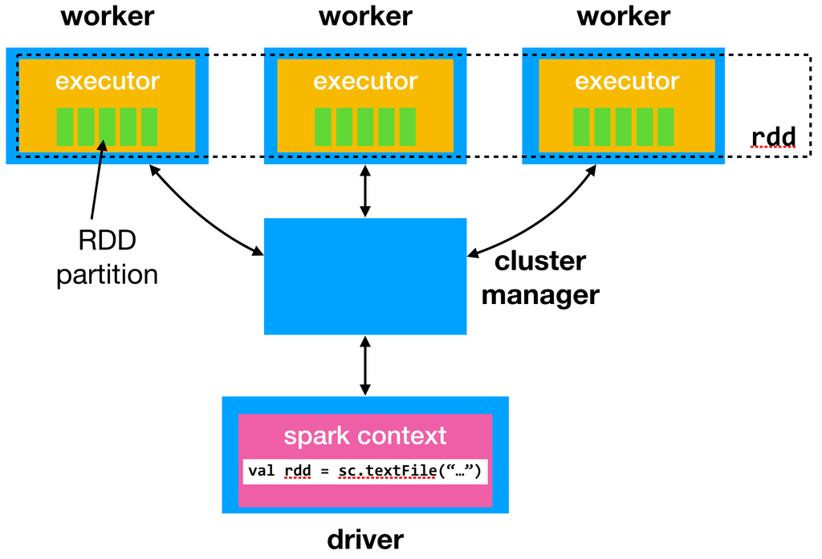

Spark cluster architecture

- *Executors* do the actual processing; *worker* nodes can contain multiple executors.
- The *driver* accepts user programs and returns processing results
- The *cluster manager* does resource allocation

## A Spark application

A Spark application:

- begins by specifying the required cluster resources, which the cluster manager seeks to fulfil. If resources are available, executors are started on worker nodes.
- creates a Spark context, which acts as the driver.
- issues a number of *jobs*, which load data partitions on the executor heap and run in threads on the executor’s CPUs
- when it finishes, the cluster manager frees the resources.

## What is a Spark job?

*Jobs* are created when an action is requested. Spark walks the RDD dependency graph *backwards* and builds a graph of stages.

*Stages* are jobs with wide dependencies. When such an operation is requested (e.g. `groupByKey` or `sort`) the Spark scheduler will need to reshuffle/repartition the data. Stages (per RDD) are always executed serially. Each stage consists of one or more tasks.

## A job graph

We can see how our job executes in we connect to our driver’s WebUI (port 4040 on the driver machine).

Here is the graph for the word counting job we saw before.

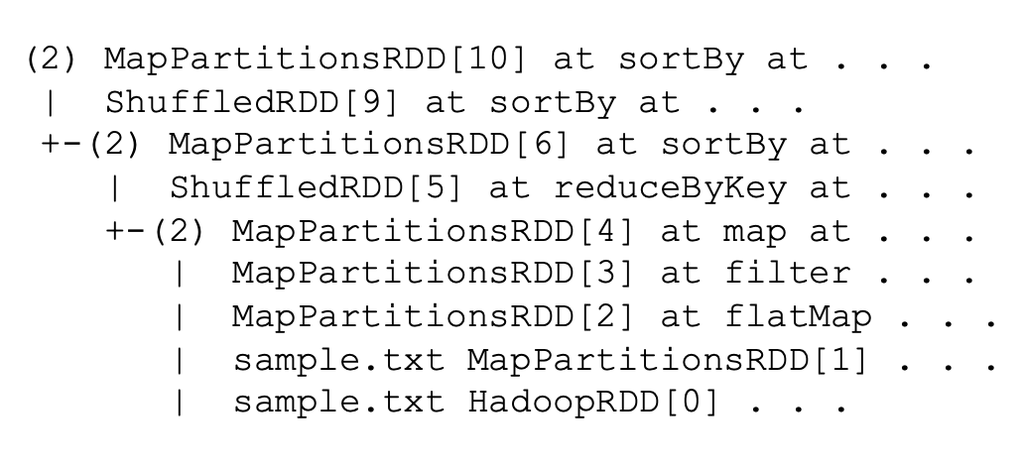

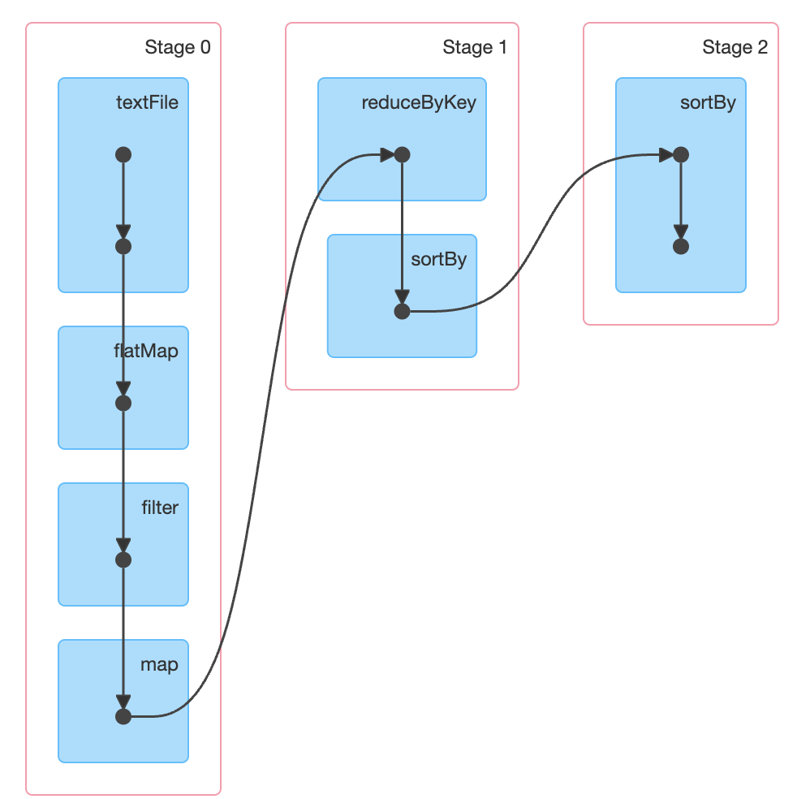

```scala
val result = sc.textFile("sample.txt")
  .flatMap(_.split(" "))
  .filter(x => x.length > 1)
  .map(x => (x, 1))
  .reduceByKey((a,b) => a + b)
  .sortBy(_._1)
```

## Fault tolerance

Spark uses RDD lineage information to know which partition(s) to recompute in case of a node failure.

Recomputing happens at the *stage* level.

To minimize recompute time, we can use checkpointing. With checkpointing we can save job *stages* to reliable storage. Checkpointing effective truncates the RDD lineage graph.

Spark clusters are reliable to node failures, but not to master failures. Running Spark on middleware such as YARN or Mesos is the only way to run multi-master setups.

# Effective Spark

## Requesting resources

Here is an example of how to start an application with a custom resource configuration.

```bash
spark-shell   \
    --master spark://spark.master.ip:7077 \
    --deploy-mode cluster  \
    --driver-cores 12
    --driver-memory 5g \
    --num-executors 52 \
    --executor-cores 6 \
    --executor-memory 30g
```

## RDDs and formatted data

RDDs by default do not impose any format on the data they store. However, if the data is formatted (e.g. log lines with known format), we can create a schema and have the Scala compiler type-check our computations.

Consider the following data ([common log format](https://en.wikipedia.org/wiki/Common_Log_Format)):

```python
127.0.0.1 user-identifier frank [10/Oct/2000:13:55:36 -0700] \
 "GET /apache_pb.gif HTTP/1.0" 200 2326
```

We can map this data to a Scala *case class*

```scala
case class LogLine(ip: String, id: String, user: String,
                   dateTime: Date, req: String, resp: Int,
                   bytes: Int)
```

and use a [regular expression](https://en.wikipedia.org/wiki/Regular_expression) to parse the data:

```
([^\s]+) ([^\s]+) ([^\s]+) ([^\s]+) "(.+)" (\d+) (\d+)
```

Then, we can use `flatMap` in combination with Scala’s pattern matching to filter out bad lines:

```scala
import java.text.SimpleDateFormat
import java.util.Date

val dateFormat = "d/M/y:HH:mm:ss Z"
val regex = """([^\s]+) ([^\s]+) ([^\s]+) ([^\s]+) "(.+)" (\d+) (\d+)""".r
val rdd = sc
    .textFile("access-log.txt")
    .flatMap ( x => x match {
      case regex(ip, id, user, dateTime, req, resp, bytes) =>
        val df = new SimpleDateFormat(dateFormat)
        new Some(LogLine(ip, id, user, df.parse(dateTime),
                         req, resp.toInt, bytes.toInt))
      case _ => None
      })
```

Then, we can compute the total traffic per month

```scala
val bytesPerMonth = rdd
    .groupBy(k => k.dateTime.getMonth)
    .aggregateByKey(0)({(acc, x) => acc + x.map(_.bytes).sum},
                      {(x,y) => x + y})
```

Notice that all code on this slide is type checked!

## Connecting to databases

The data sources that Spark can use go beyond `textFile`s. Spark can connect to databases such as

- MongoDB

```scala
val readConfig = ReadConfig(Map("uri" -> "mongodb://127.0.0.1/github.events"))
sc.loadFromMongoDB(readConfig)
val events = MongoSpark.load(sc, readConfig)

events.count
```

- MySQL or Postgres over JDBC

```scala
val users = spark.read.format("jdbc").options(
  Map("url" ->  "jdbc:mysql://localhost:3306/ghtorrent?user=root&password=",
  "dbtable" -> "ghtorrent.users",
  "fetchSize" -> "10000"
  )).load()

users.count
```

or to distributed file systems like HDFS, Amazon S3, Azure Data Lake etc

## Optimizing partitioning

Partitioning becomes an important consideration when we need to run iterative algorithms. Some cases benefit a lot from defining custom partitioning schemes:

- Joins between a large, almost static dataset with a much smaller, continuously updated one.
- `reduceByKey` or `aggregateByKey` on RDDs with arithmetic keys benefit from range partitioning as the shuffling stage is minimal (or none) because reduction happens locally!

## Broadcasts

From the [docs](http://spark.apache.org/docs/latest/rdd-programming-guide.html#broadcast-variables): Broadcast variables allow the programmer to keep a read-only variable cached on each machine rather than shipping a copy of it with tasks.

Broadcasts are often used to ship precomputed items, e.g. lookup tables or machine learning models, to workers so that they do not have to retransfer them on every shuffle.

With broadcasts, we can implement efficient in-memory joins between a processed dataset and a lookup table.

```scala
val curseWords = List("foo", "bar") // Use your imagination here!
val bcw = sc.broadcast(curseWords)

odyssey.filter(x => !curseWords.contains(x))
```

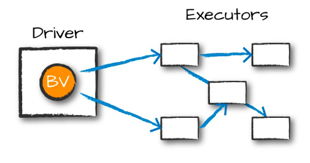

## Accumulators

Some times we need to keep track of variables like performance counters, debug values or line counts while computations are running.

```scala
// Bad code
var taskTime = 0L
odyssey.map{x =>
  val ts = System.currentTimeMillis()
  val r = foo(x)
  taskTime += (System.currentTimeMillis() - ts)
  r
}
```

To make it work, we need to define an accumulator

```scala
val taskTime = sc.accumulator(0L)
odyssey.map{x =>
  val ts = System.currentTimeMillis()
  val r = foo(x)
  taskTime += (System.currentTimeMillis() - ts)
  r
}
```

Using accumulators is a *side-effecting* operation and should be avoided as it complicates design. It is important to understand that accumulators are aggregated at the *driver*, so frequent writes will cause large amounts of network traffic.

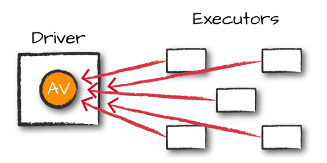

# Spark’s Toolkit

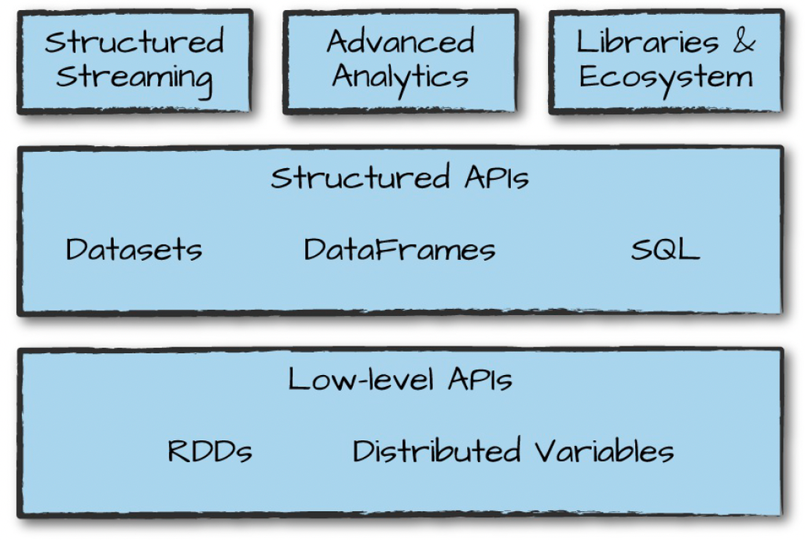

## Image credits

- [Hadoop processing model](http://www.hostingadvice.com/how-to/what-is-hadoop/)
- The DryadLINQ image is from the DryadLINQ OSDI 08 paper.
- [How Map/Reduce works?](http://blog.sqlauthority.com)
- Spark partition dependencies image is from the Spark OSDI paper.
- Spark persistence storage levels from the [Spark documentation](https://spark.apache.org/docs/latest/rdd-programming-guide.html#rdd-persistence)
- Images for groupByKey and reduceByKey
- Images for broadcast variables and accumulators from [3]
- Image for Spark’s toolkit from [3]

## Bibliography

[1]

R. Lämmel, “Google’s MapReduce programming model—revisited,” *Science of computer programming*, vol. 70, no. 1, pp. 1–30, 2008.

[2]

J. Dean and S. Ghemawat, “MapReduce: Simplified data processing on large clusters,” 2004.

[3]

B. Chambers and M. Zaharia, *Spark: The definitive guide*. O’Reilly Media, Inc., 2017.

[4]

M. Zaharia, M. Chowdhury, M. J. Franklin, S. Shenker, and I. Stoica, “Spark: Cluster computing with working sets.” *HotCloud*, vol. 10, no. 10–10, p. 95, 2010.

[5]

Y. Yu *et al.*, “[DryadLINQ: A system for general-purpose distributed data-parallel computing using a high-level language](http://dl.acm.org/citation.cfm?id=1855741.1855742),” in *Proceedings of the 8th USENIX conference on operating systems design and implementation*, 2008, pp. 1–14.

[6]

C. Chambers *et al.*, “[FlumeJava: Easy, efficient data-parallel pipelines](http://dl.acm.org/citation.cfm?id=1806638),” in *ACM SIGPLAN conference on programming language design and implementation (PLDI)*, 2010, pp. 363–375.

## Copyright

This work is (c) 2017, 2018, 2019, 2020, 2021 - onwards by TU Delft and Georgios Gousios and licensed under the [Creative Commons Attribution-NonCommercial-ShareAlike 4.0 International](http://creativecommons.org/licenses/by-nc-sa/4.0/) license.